# Target sequence duplication rate

Fritjof Lammers

## Questions

1. What is the probability of sampling the same DNA fragment (same length, same position) from a pool of DNA molecules?
2. Given that depth of coverage is uniform across the genome/the targets, at depth of coverage would you re-sample identical DNA fragments?

## Ideas

Let’s define the target size $T$, from which DNA fragments are generated.

The fragment size distribution follows a poission distribution with mean $I$.

The probability of sampling a fragment of size $l_f$ from the distribution is given by the poission distribution `dpois(l_f,I)`.

```r
T <- 49e6
I <- 200
```

## Number of DNA fragments sequenced

To obtain the target coverage $C$, with a read length of 100 bp ($r$), the number of fragments follows the Lander-Waterman equation.

$ n_f = C * T / r*2 $

Generate some example fragment counts for $C \in \{50,1000\}$

```r
r = 100 # read length
C = seq(50,1000,50) # list of target coverage
n_f = C * T / r*2 # fragment count
```

## Probability of sampling the fragment of the same length

Sampling a poission distribution with mean $I$ and determine and maximum and minimum length that occurr.

For each length in this range, store the probability $P(frag = x)$ of sampling in the vector `prop_sampling`.

The probability of sampling a fragmengt of the identical length should be $P(ident,x) = P(frag=x)^2$

```r
dist_I <- rpois(1e6,I)
possible_fragment_lengths <- min(dist_I):max(dist_I)
prob_sampling <- vector()
for (i in possible_fragment_lengths) {
  prob_sampling[i] <- dpois(i, I)
}
```

??? For $n_f$ number of fragments, the chance of re-sampling an identical one is thus $P(resample) = \sum{P(ident,x)}$ ???

```r
n_f_test <- 1000
prob_list <- unlist(lapply(rpois(n_f_test, I),
       function (x) prob_sampling[x]^2
       ))
```

# Scribbles and scratches

## Simplified assumption

Assuming that the fragement size is uniform $F = 200$ the probability sampling an identical fragment from the target region space ($T$)is

Under the more realistic assumption that the insert size distribution follows a poission distribution

```r
is <- 200
num_fragments = c(1e6,1e7,1e8)
is_dist <- rpois(num_fragments,is)
range_dist <- min(is_dist):max(is_dist)

p_sample <- unlist(lapply(range_dist, function (x) length(which(is_dist == x))))

p_same <- (p_sample^2)/T
p_same
```

```
##  [1] 2.040816e-08 0.000000e+00 0.000000e+00 0.000000e+00 0.000000e+00
##  [6] 0.000000e+00 0.000000e+00 0.000000e+00 0.000000e+00 0.000000e+00
## [11] 0.000000e+00 0.000000e+00 0.000000e+00 0.000000e+00 0.000000e+00
## [16] 0.000000e+00 0.000000e+00 0.000000e+00 0.000000e+00 0.000000e+00
## [21] 0.000000e+00 0.000000e+00 2.040816e-08 0.000000e+00 0.000000e+00
## [26] 0.000000e+00 2.040816e-08
```

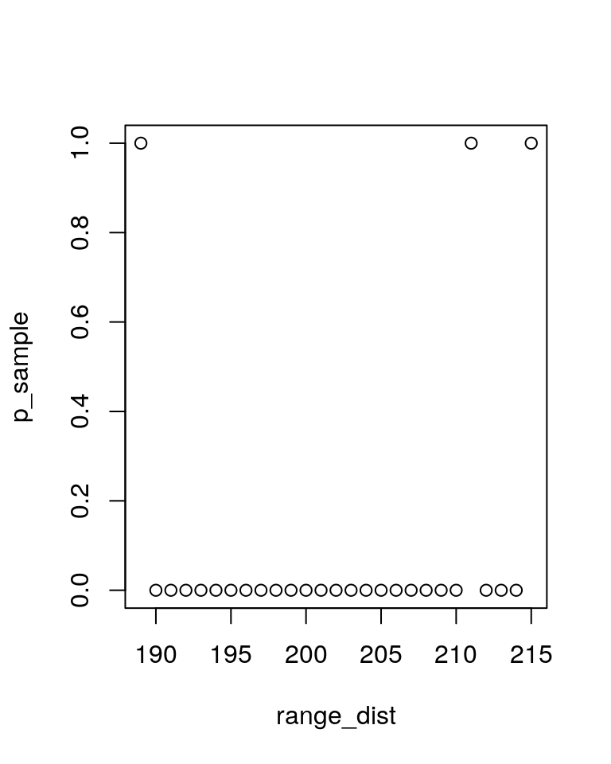

```r
plot(range_dist, p_sample)
```

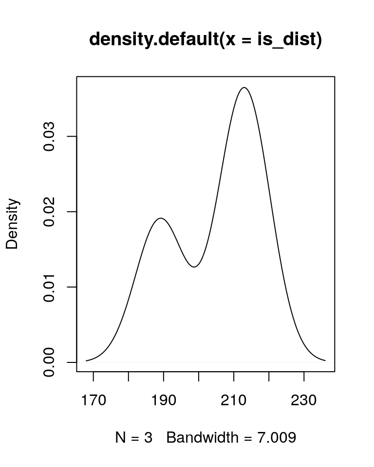

```r
plot(density(is_dist))
```

Hence, the new probability sampling the same fragment depends on the probability having the identical insert size.

We need to calculate the probability to sample the same fragment size from the fragment size distribution

$P(ident) = 1/T*P(frag)$

```r
p_ident <- 1/T*p_sample
1/p_ident
```

```
##  [1] 4.9e+07     Inf     Inf     Inf     Inf     Inf     Inf     Inf
##  [9]     Inf     Inf     Inf     Inf     Inf     Inf     Inf     Inf
## [17]     Inf     Inf     Inf     Inf     Inf     Inf 4.9e+07     Inf
## [25]     Inf     Inf 4.9e+07
```